# Value at Risk, método de varianza-covarianza

Elias Alegria Pavez (elias.alegria@ug.uchile.cl)

24 de julio de 2018

## Introducción

En este documento, se importarán datos de acciones entre los años 2014 y 2017 con la finalidad de calcular el Value at Risk (VaR) para los años 2016 y 2017 con una ventana móvil de 504 días (dos años en días transables), mediante el método de varianza-covarianza.

## Packetes a utilizar

Se utilizarán los siguientes paquetes de R:

1. **dplyr**: Principalmente porque permite manejar los datos de una manera fácil mendiante la utilización de funciones como `mutate`, `summarize`, `group_by`, etc. Además se utilizará el *Pipe Operator:* `%>%` para trabajar de forma más ituitiva.
2. **tidyr**: Para el manejo de datos, es útil para agrupar y desagrupar datos con sus funciones `gather` y `spread`.
3. **ggplot2**: Para la visualización de datos.
4. **plotly**: Se combina con ggplot, utilizando el comando `ggplotly` para realizar gráficos interactivos.
5. **quantmod**: Escencial para importar datos financieros y trabajar con series de tiempo.

```r
library(dplyr)
library(tidyr)
library(ggplot2)
library(quantmod)
library(plotly)
```

### Importar los datos

La función `getSimbols` permite importar como series de tiempo los datos de las acciones. Para importar mas de una serie de tiempo, se separan por `;`.

```r
getSymbols("AAPL;AMZN;FB;MSFT;NKE", source='yahoo', from=as.Date('2014-01-01'), to=as.Date('2017-12-31'))
```

```
## [1] "AAPL" "AMZN" "FB"   "MSFT" "NKE"
```

Veamos por ejemplo, la serie de tiempo de Apple:

```r
head(AAPL)
```

```
##            AAPL.Open AAPL.High AAPL.Low AAPL.Close AAPL.Volume
## 2014-01-02  79.38286  79.57571 78.86000   79.01857    58671200
## 2014-01-03  78.98000  79.10000 77.20428   77.28286    98116900
## 2014-01-06  76.77857  78.11429 76.22857   77.70428   103152700
## 2014-01-07  77.76000  77.99429 76.84571   77.14857    79302300
## 2014-01-08  76.97285  77.93714 76.95571   77.63715    64632400
## 2014-01-09  78.11429  78.12286 76.47857   76.64571    69787200
##            AAPL.Adjusted
## 2014-01-02      67.72286
## 2014-01-03      66.23527
## 2014-01-06      66.59647
## 2014-01-07      66.12019
## 2014-01-08      66.53890
## 2014-01-09      65.68922
```

Y se puede visualizar, ocupando la función `chartSeries` de quantmod.

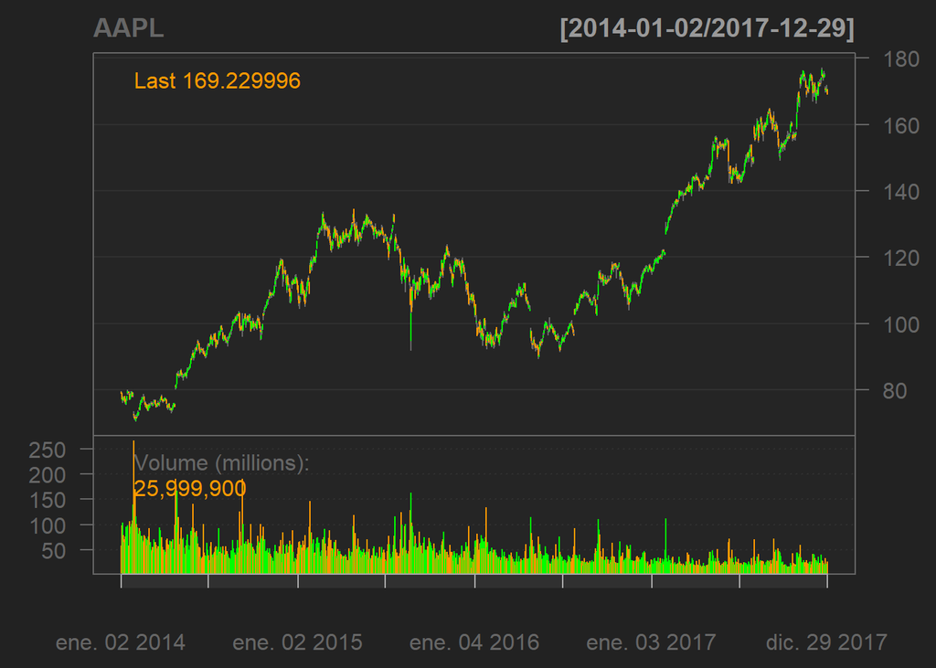

```r
chartSeries(AAPL)
```

Ahora, se ocuparán los precios *Adjusted* para el cáculo del VaR, transformaremos la serie en en data frame y nos quedaremos con la columna Adjusted y una columna Date.

```r
NKE <- NKE %>% as.data.frame() %>% mutate(date=index(NKE)) %>% select(date,NKE.Adjusted)
AMZN <- AMZN %>% as.data.frame() %>% mutate(date=index(AMZN)) %>% select(date,AMZN.Adjusted)
FB <- FB %>% as.data.frame() %>% mutate(date=index(FB)) %>% select(date,FB.Adjusted)
MSFT <- MSFT %>% as.data.frame() %>% mutate(date=index(MSFT)) %>% select(date,MSFT.Adjusted)
AAPL <- AAPL %>% as.data.frame() %>% mutate(date=index(AAPL)) %>% select(date,AAPL.Adjusted)

# veamos Apple ahora
head(AAPL)
```

```
##         date AAPL.Adjusted
## 1 2014-01-02      67.72286
## 2 2014-01-03      66.23527
## 3 2014-01-06      66.59647
## 4 2014-01-07      66.12019
## 5 2014-01-08      66.53890
## 6 2014-01-09      65.68922
```

Lo siguiente es realizar un join para tener todos los datos en un data frame. Esto lo hacemos con la función `inner_join` de dplyr.

```r
precios <- NKE %>%
    inner_join(AMZN, by='date') %>%
    inner_join(FB, by='date') %>%
    inner_join(MSFT, by='date') %>%
    inner_join(AAPL, by='date') %>% tbl_df

# renombramos las columnas para evitar tener el '.Adjusted'
colnames(precios) <- c('date','NKE','AMZN','FB','MSFT','AAPL')

#veamos la data
head(precios)
```

```
## # A tibble: 6 x 6
##   date         NKE  AMZN    FB  MSFT  AAPL
##   <date>     <dbl> <dbl> <dbl> <dbl> <dbl>
## 1 2014-01-02  35.9  398.  54.7  33.2  67.7
## 2 2014-01-03  35.8  396.  54.6  33.0  66.2
## 3 2014-01-06  35.6  394.  57.2  32.3  66.6
## 4 2014-01-07  35.6  398.  57.9  32.6  66.1
## 5 2014-01-08  35.4  402.  58.2  32.0  66.5
## 6 2014-01-09  35.4  401.  57.2  31.8  65.7
```

### Cálculo de retornos

Se calcularán los retosnos logarítmicos: $r_t=ln(\frac{p_t}{p_{t-1}})$. Se ocupará la función `transmutate` de dplyr para crear las variables y eliminar las restantes.

```r
retornos <- precios %>% transmute(
    date = date,
    NKE = log(NKE/lag(NKE)),
    AAPL = log(AAPL/lag(AAPL)),
    AMZN = log(AMZN/lag(AMZN)),
    FB = log(FB/lag(FB)),
    MSFT = log(MSFT/lag(MSFT))
)

# veamos la data
head(retornos)
```

```
## # A tibble: 6 x 6
##   date              NKE      AAPL      AMZN        FB      MSFT
##   <date>          <dbl>     <dbl>     <dbl>     <dbl>     <dbl>
## 1 2014-01-02  NA         NA        NA        NA        NA
## 2 2014-01-03  -0.00269   -0.0222   -0.00385  -0.00275  -0.00675
## 3 2014-01-06  -0.00772    0.00544  -0.00711   0.0473   -0.0214
## 4 2014-01-07   0.000775  -0.00718   0.0111    0.0125    0.00772
## 5 2014-01-08  -0.00518    0.00631   0.00973   0.00534  -0.0180
## 6 2014-01-09   0.        -0.0129   -0.00227  -0.0175   -0.00645
```

Ahora visualicemos los retornos de las acciones:

[interactive chart not shown]

### Cálculo del VaR

Para el cálculo del value at risk, se utilizará la siguiente fórmula:

$$VaR_{t,t+1}=\left(e^{\left(\mu-\frac{\sigma^2}{2}\right)+\sigma\psi}-1\right)M$$

Donde $\mu$ y $\sigma^2$ son la media y la varianza de los retornos logarítmicos, $\psi$ es la inversa de una $N(0,1)$ con probabilidad $\alpha$ y $M$ es la cantidad invertida en el activo. Para este caso utilizaremos un $\alpha=0,05$, por lo que la inversa de la normal de un 95% es $\psi=1,64$ aprox. Además supondremos que se invertirá una cantidad de $10000 en cada activo.

#### Seteamos los parámetros:

```r
alpha <- .05
psi <- qnorm(1-alpha)
M <- 10000
```

#### Creamos la función del VaR:

```r
varCov <- function(u,sigma,psi,M) {
    return(
        (exp((u-sigma^2/2)+sigma*psi)-1)*M
    )
}
```

#### Cálculo con ventana móvil:

Se iterará con dos ciclos, uno para cada stock y otro para cada día:

```r
# Se crea una matriz que almacenará los VaR para cada acción desde 2016 a 2017
VAR <- matrix(1:503, nrow = 503, ncol = 5)
colnames(VAR) <- colnames(retornos[,2:6])

# Se realiza el loop
for (s in 1:5) {
    for (i in VAR[,s]) {
        u <- mean(retornos[i:(i+503),][[s+1]], na.rm = T)
        sigma <- sd(retornos[i:(i+503),][[s+1]], na.rm = T)
        VAR[i,s]=varCov(u,sigma,psi,M)
    }
}

# veamos la matriz de VaR
head(VAR)
```

```
##           NKE     AAPL     AMZN       FB     MSFT
## [1,] 236.7870 265.2560 355.5393 336.8330 259.2130
## [2,] 236.5622 264.9994 356.8731 336.5273 258.8857
## [3,] 237.0831 265.1019 356.8589 336.6840 259.0662
## [4,] 237.1429 265.0161 356.9222 333.9420 258.9893
## [5,] 237.5286 266.2650 357.1175 334.8111 259.5069
## [6,] 237.6212 266.2325 356.8286 334.6047 259.5510
```

Luego, se crea un data frame con la fecha(date) y el VaR de cada acción

```r
# se transforma en data frame la matriz VAR
VAR <- data.frame(VAR)
# se combina la data para obtener date y VaR de cada acción
VAR <- cbind(date=retornos[505:1007,1],VAR) %>% tbl_df

# veamos la data
head(VAR)
```

```
## # A tibble: 6 x 6
##   date         NKE  AAPL  AMZN    FB  MSFT
##   <date>     <dbl> <dbl> <dbl> <dbl> <dbl>
## 1 2016-01-04  237.  265.  356.  337.  259.
## 2 2016-01-05  237.  265.  357.  337.  259.
## 3 2016-01-06  237.  265.  357.  337.  259.
## 4 2016-01-07  237.  265.  357.  334.  259.
## 5 2016-01-08  238.  266.  357.  335.  260.
## 6 2016-01-11  238.  266.  357.  335.  260.
```

#### Visualización del VaR

Finalmente, podemos ver gráficamente el VaR de cada acción, agrupando la data con `gather` para gráficar más fácimente:

```r
g2 <- VAR %>% gather(Stock, VaR, 2:6) %>%
    ggplot(aes(x=date, y=VaR, color=Stock)) + geom_line() + theme_test() + xlab('Date') + ggtitle('Value at Risk')

ggplotly(g2)
```

[interactive chart not shown]

**Nota:** Esto es parte de una tarea para el ramos de Finanza II. Cualquier consulta sobre el código a elias.alegria@ug.uchile.cl